# Guide MVP v1

# Serotonin syndrome

Serotonin syndrome occurs when the brain is flooded with serotonin. Symptoms may include dilated pupils, shivering, sweating, an increased heart rate and abnormal heartbeat, fever, as well as jerking or twitching. (see below)

In the event of severe serotonin syndrome, **it’s important that it is correctly identified as such** by the medical professionals who assist you. So, it’s important to understand when you’re most at risk, and what the symptoms are.

Serotonin syndrome is *dose-dependent*. That means it’s difficult to tell in advance whether a combination of drugs will be risky or not: It depends on the dose taken, and on the timing. That’s why we advise you, before taking DMT, to **talk to your doctor about everything you’re taking (including supplements and herbs), and to be with a sitter at least the first few times you take DMT**.

## Symptoms and what to do

If, after taking DMT while on one or several other serotonergic drugs, you suspect you have serotonin syndrome, **call your healthcare provider**, and don’t take more serotonergic drugs (including DMT). If the symptoms are severe or rapidly worsening, immediately call the emergency services.

**Immediately call emergency services if you have any of the following severe symptoms**:

- Fainting / unconsciousness
- High fever (greater than 101.3 degrees Fahrenheit, or 38.5 degrees Celsius)
- Tremor (involuntary movements) or severe muscle rigidity
- Fast heart rate / irregular heartbeat, plus feeling very unwell
- Seizure
- Milder symptoms that are rapidly worsening ￼

Other serotonin syndrome symptoms include:

- Agitation or restlessness
- Insomnia
- Confusion
- Rapid heart rate
- Dilated pupils
- Loss of muscle coordination or twitching muscles
- High blood pressure
- Muscle rigidity
- Heavy sweating
- Diarrhea
- Headache
- Shivering
- Goose bumps

For more information, you can consult:

- [Demystifying Serotoning Syndrome](https://www.cfp.ca/content/64/10/720)
  - See also this [info sheet](https://www.cfp.ca/content/cfp/suppl/2018/10/11/64.10.720.DC1/720_SS_Infographic_Patient.pdf)
- [Cleveland clinic](https://my.clevelandclinic.org/health/diseases/17687-serotonin-syndrome?utm_source=chatgpt.com)
- [Mayo clinic](https://www.mayoclinic.org/diseases-conditions/serotonin-syndrome/symptoms-causes/syc-20354758?utm_source=chatgpt.com)

## Causes of serotonin syndrome

Serotonin syndrome is most likely when two or more serotonergic agents are combined, especially when they act via different mechanisms. You’re most at risk of serotonin syndrome risk when DMT is taken in combination with:

1. MAOIs (see below);
   1. Typically taken for treatment-resistant depression, or as psychedelic plant brews.
2. Multiple other drugs whose serotonergic effects stack up (see below).
   1. For example: DMT + an SSRI + dextromethorphan.

### MAOIs

The highest-risk involves pairing DMT with MAOIs (monoamine oxidase inhibitors). MAOIs slow down the elimination of serotonin by the body. That means serotonin can build up to a high level, triggering the syndrome.

Because MAOIs prolong the effect of DMT, it’s possible for the serotonin syndrome to develop or worsen several hours after DMT is taken.

MAOIs also turns DMT into a more potent psychedelic: You might have a much more intense and longer trip than on the same dose without MAOIs. This in itself can be psychologically tolling.

Common MAOIs include:

- Certain antidepressants
  - Notably: phenelzine, tranylcypromine, isocarboxazid and moclobemide
- Certain antibiotics
  - Notably isoniazid and linezolid
- Plant-based MAOIs like ayahuasca brews, Syrian rue, harmine/harmaline blends (“changa” can include these)

### Combinations with more than two drugs

A serotonin syndrome might be triggered by a combination of DMT + two or more drugs that elevate serotonin levels. Even if each drug is safe in isolation, their effects can stack up, especially if they elevate serotonin each in a different way.

There are many serotonergic drugs. Most of them are used as antidepressants or painkillers. The main categories are:

- *Serotonin reuptake inhibitors*. This category includes:
  - SSRIs
    - Notably: citalopram, escitalopram, fluoxetine, fluvoxamine, paroxetine, and sertraline
  - SNRIs
    - Notably: venlafaxine, tramadol (also an opioid)
  - Certain TCAs (tricyclic antidepressants):
    - Notably: clomipramine and imipramine
  - Certain opioids:
    - Notably: tramadol, methadone, meperidine, fentanyl
    - (Morphine is *not* thought to have a dangerous interaction)
  - Certain antihistamines:
    - Notably: chlorpheniramine and brompheniramine
  - Dextromethorphan
  - Certain plants
    - Notably: St John’s wort
- *Serotonin releasers*. This category includes:
  - Amphetamine
  - Ecstasy (3,4-methylenedioxymethamphetamine)

## Triptans

#### Serotonin syndrome

Triptans are thought to be unlikely to contribute to serotonin syndrome (see e.g. [here](https://www.cfp.ca/content/64/10/720), [here](https://en.wikipedia.org/wiki/Triptan#Interactions)). Caution is advised nonetheless, as they interact with the serotonin system.

#### Cardiovascular risks

Taking DMT shortly after triptans can significantly stress the heart. This is because triptans narrow blood vessels, and DMT can increase heart rate and blood pressure.  
If a triptan was taken, a washout period of at least 24 hours (roughly 5 half-lives for most triptans) is safer before attempting DMT.

# Physiological and psychological effects of DMT

DMT hasn’t been very much researched yet. So, we lack scientific data about what the psychological effects of DMT at different dosages might be. That said, the evidence we have so far points to DMT being:

- **Extremely unlikely to trigger severe psychological effects, such as psychosis**. This is already extremely unlikely at high doses (50 mg or more), and even less likely at doses typically sufficient to abort attacks (5-10 mg). (more)
  - It’s important to note that people suffering from psychotic disorders (like schizophrenia) are usually excluded from clinical trials. So, we know very little about the risks for them. If you’re in that situation, we recommend you exercise caution. Talk to your doctor, and don’t take DMT if you’re not absolutely sure it’s safe for you.
- **Likely to cause non-dangerous (but potentially unpleasant) effects** such as feeling cold, feeling your heart racing, being anxious, or seeing fractal patterns. (more)
  - Whether the effects will be pleasant or not critically depends on your environment and your mindset.

## Severe psychological effects: more details

The scientific evidence we have on DMT points to a **safe psychological profile**. Here are for example results pulled out from [two recent](https://jamanetwork.com/journals/jamapsychiatry/fullarticle/2822968) [meta-analyses](https://www.nature.com/articles/s41380-024-02800-5):

- **In clinical studies with healthy volunteers:** None of the clinical studies analyzed in the two meta-analyses reports severe adverse events (i.e., symptoms that require hospitalization or are life-threatening -- this include, but is not limited to, psychosis), either immediately upon taking DMT, or later.
- **Among ayahuasca users:** In a population study[^2] of users of ayahuasca (a herbal decoction containing DMT), persistent psychotic problems were estimated to be exceptionally rare (1 in 50,000 cases). Similar numbers were reported in a population study of users of peyote (a plant containing another psychedelic, mescaline).
- **In clinical studies with psychotic patients:** We lack clinical data regarding DMT. That said, historical data (1950s-70s) on administering LSD[^3] to patients with schizophrenia suggests a risk of psychedelic-induced psychosis of about 3.8% in that specific population. In almost all cases no long-lasting psychotic symptoms were observed.

It’s furthermore important to note that, in many studies, the dose is **much higher than what’s sufficient to abort attacks** (typically at least 50 mg, compared to 5-10 mg).

## Non-severe effects: more details

It’s common for DMT users to experience a variety of non-dangerous effects, ranging from pleasant to unpleasant. **All effects are generally reported to start after a few seconds, to peak around 1 minute, and disappear after 10-20 minutes.**

On a 5 to 10 mg dose, which is most likely sufficient to abort an attack, you’re likely to:

- Feel your heart racing, as if you just climbed stairs quickly.
- Feel cold, and perhaps sweat.

You might also feel dizzy, lightheaded or nauseous, or have difficulty moving your limbs. Those symptoms are part of the normal bodily response to an increase in serotonin activity in the brain. They’ll disappear after 10-20 minutes. If they don’t, be mindful of the serotonin syndrome, and take action if necessary.  
You can consult the two tables [here](https://docs.google.com/spreadsheets/d/1Rbid86bUAh0uZE5azsC4i81UszpmavoUgVLSyqB-nHM/edit?usp=sharing) for a more comprehensive list of bodily symptoms (not limited to small doses).

Your perceptions and feelings will also likely be slightly altered:

- You’ll likely feel a warm or buzzing sensation in the body. You might also feel like gravity suddenly increased.
- You might see visual patterns (such as fractals or mandala-like patterns) with eyes closed.
- You might hear a high-pitched ringing sound.

You might also feel nervous or anxious. If it’s the case, remember that the effects will be gone within 10-20 minutes.

Stronger effects will appear at higher doses:

- Visual patterns with eyes open, or even a complete disappearance of the room you’re in
- Strong feelings, e.g. of meaningfulness, of kindness or of fear.
- Seeing or feeling the presence of an entity (sometimes referred to as an “encounter”).
  - The encounter is most often reported to be positive (benevolent or guiding entity) to neutral. In ~10% of the cases, the encounter is perceived as negative.
- A sense of dissociation from your body, or a sense of a loss of self (ego death)

# Mixing DMT powder with vape juice

# Image guide

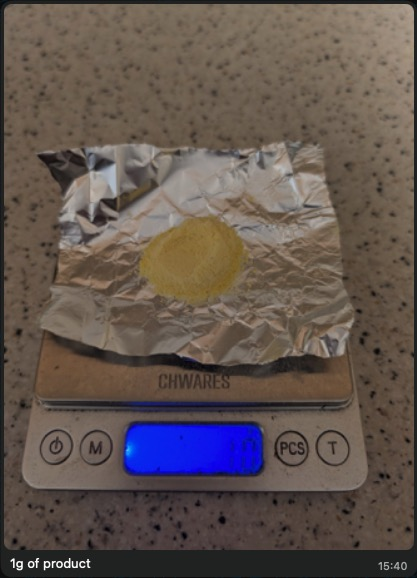

DMT on scale

[figure not shown]

Vape juice bottle

[figure not shown]

Juice in small bottle

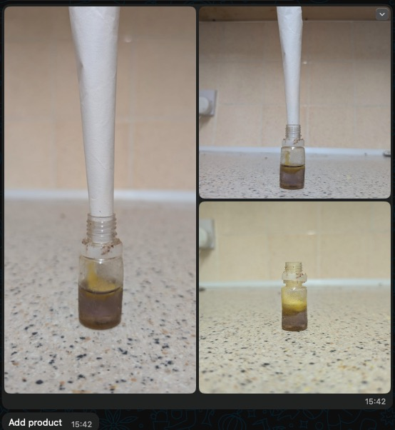

Adding DMT to bottle

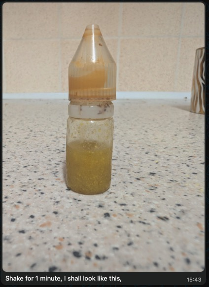

Shake mixture

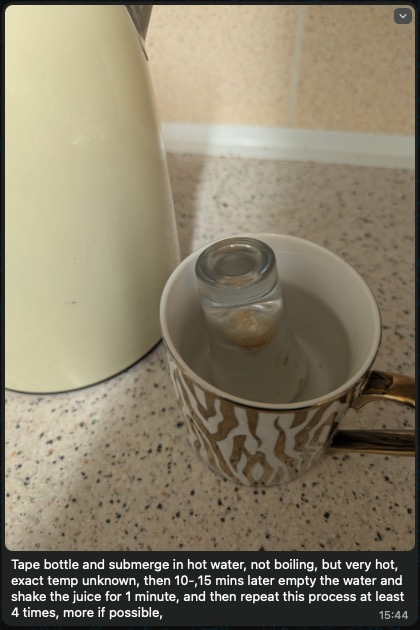

Hot water bath

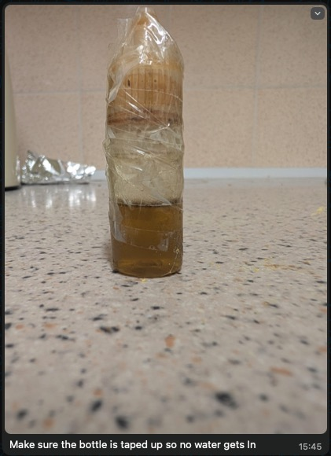

Taped bottle

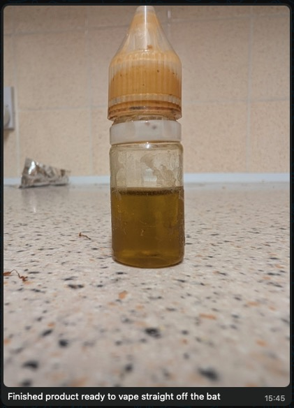

Finished product

# Written guide (written by Gemini)

#### **1. Equipment Needed**

- **The Ingredients:**
  - **DMT Crystal:** (Freebase form).
  - **The Liquid Base:** 100% Propylene Glycol (PG) **OR** a mix of PG and Vegetable Glycerin (VG).
    - *Recommendation:* A **70% PG / 30% VG** mix or **50/50** is best. Pure PG dissolves crystal best but is harsh; adding a little VG smooths it out.
- **The Tools:**
  - Small **Shot Glass** (glass is mandatory; plastic may melt or leach).
  - **Blunt-Tip Syringe** (1ml or larger).
  - A bowl of **Hot Water** (from the tap is fine; boiling is risky).
  - **Stirring Tool** (Stainless steel dab tool or a clean paperclip).

#### **2. The Process (Step-by-Step)**

**Step A: Measure**

1. Weigh your DMT. Let’s assume you are using **1 gram**.
2. Measure your liquid using the syringe.
   - **For the 1:1 Ratio (Standard):** Measure exactly **1mL** of your PG/VG liquid.
   - *Note:* If you are worried about harshness, you can start with 0.7mL of PG, dissolve the crystal, and then add 0.3mL of VG.

**Step B: Combine**

1. Place the **1g of crystal** into the bottom of the dry shot glass.
2. Squirt the **1mL of liquid** directly onto the crystals.
3. *Observation:* It will look slushy, cloudy, and clumpy. It will not dissolve yet.

**Step C: The Heat Bath**

1. Fill a bowl with **hot water** (approx 60°C–70°C / 140°F–160°F). It should be hot to the touch but not boiling.
2. Place the **shot glass** into the water. Ensure the water level is high enough to warm the mixture but **low enough that no water splashes inside** the shot glass. Water will ruin the solution.
3. Let it sit for 2–3 minutes to warm up.

**Step D: Stir and Dissolve**

1. As the mixture warms, the liquid will become thinner (less viscous).
2. **Stir gently** with your metal tool.
3. Keep stirring until the liquid is **completely clear** and amber/yellow.
   - *The “Light Check”:* Hold the glass up to a light. If you see *any* floating specks, clouds, or swirls, it is **not done**. Put it back in the heat and stir longer.
   - *Why this matters:* Even tiny undissolved crystals will get sucked into the cartridge’s intake holes and clog the coil, rendering the pen useless during an attack.

**Step E: Transfer to Cartridge**

1. While the liquid is still warm and thin, suck it all up into the **syringe**.
2. Inject it into the **cartridge** tank.
   - *Tip:* Slide the needle down the side of the glass to let the oil settle at the bottom. Avoid injecting it into the center chimney (airflow tube).
3. Screw the mouthpiece on immediately.

**Step F: The Wicking (Crucial)**

1. **Do NOT use the pen yet.**
2. Let the filled cartridge sit upright for **at least 30 minutes** (ideally 1 hour).
   - *Reason:* The ceramic coil needs time to absorb the thick liquid. If you fire the button while the ceramic is dry, you will burn the coil instantly, and the cartridge will taste like burnt rubber forever.

#### **Troubleshooting: “It Recrystallized!”**

If you leave the pen in a cold room, you might see the liquid turn solid or “slushy” with white crystals. This is normal for 1:1 ratios.

- **Do not throw it away.**
- **The Fix:**
  1. Put the cartridge into a waterproof Ziploc bag.
  2. Submerge the bag in a cup of hot water for 5 minutes.
  3. Take it out and shake it. The heat will re-dissolve the crystals, and it will be clear again.
  4. *Prevention:* Store your pen at room temperature, not in a cold car or basement.
[^1]: See e.g. [Thomas 2024](https://link.springer.com/chapter/10.1007/7854_2024_508)
[^2]: Lima FAS, Tófoli LF, Labate B, Jungaberle H. *An epidemiological surveillance system by the UDV: mental health recommendations concerning the religious use of Hoasca*. Published in *The Internationalization of Ayahuasca*.
[^3]: “These patients had from one to three sessions of LSD (10-120 µg oral LSD, and IV 0.5-10 µg/kg LSD)”